# Foundations of Data Science Project - Diabetes Analysis

## Context

Diabetes is one of the most frequent diseases worldwide and the number of diabetic patients are growing over the years. The main cause of diabetes remains unknown, yet scientists believe that both genetic factors and environmental lifestyle play a major role in diabetes.

A few years ago research was done on a tribe in America which is called the Pima tribe (also known as the Pima Indians). In this tribe, it was found that the ladies are prone to diabetes very early. Several constraints were placed on the selection of these instances from a larger database. In particular, all patients were females at least 21 years old of Pima Indian heritage.

## Objective

Here, we are analyzing different aspects of Diabetes in the Pima Indians tribe by doing Exploratory Data Analysis.

## Data Dictionary

The dataset has the following information:

- Pregnancies: Number of times pregnant
- Glucose: Plasma glucose concentration over 2 hours in an oral glucose tolerance test
- BloodPressure: Diastolic blood pressure (mm Hg)
- SkinThickness: Triceps skin fold thickness (mm)
- Insulin: 2-Hour serum insulin (mu U/ml)
- BMI: Body mass index (weight in kg/(height in m)^2)
- DiabetesPedigreeFunction: A function which scores likelihood of diabetes based on family history.
- Age: Age in years
- Outcome : Class variable (0: person is not diabetic or 1: person is diabetic)

## Q 1: Import the necessary libraries and briefly explain the use of each library (3 Marks)

```python
import numpy as np
import pandas as pd

import seaborn as sns
import matplotlib.pyplot as plt
%matplotlib inline
```

#### Write your Answer here:

Ans 1:

- numpy:
  - NumPy is a python package that **stands for ‘Numerical Python’**. It is a python package for consolidating the **handling of numbers** on numerical analysis or numerical methoods.
  - NumPy is for when we are dealing with **numbers, instead of data**.
  - Numpy is the core library for scientific computing, which contains a powerful n-dimensional array object, provides tools for integrating C, C++, etc.
- pandas:
  - Pandas contains data structures and data manipulation tools designed for **data cleaning and analysis**.
  - While pandas adopt many coding idioms from NumPy, the biggest difference is that **pandas is designed for working with tabular or heterogeneous data**. NumPy, by contrast, is best suited for working with homogeneous numerical array data.
  - The name Pandas is derived from the term **“panel data”**, an econometrics term for multidimensional structured data sets.
- seaborn:
  - Seaborn is a Python **visualization library based on matplotlib**. The library provides a high-level interface **for plotting statistical graphics**. As the library uses matplotlib in the backend, **we can use the functions in matplotlib along with functions in seaborn**.
  - Various functions in the seaborn library allow us to **plot complex and advance statistical plots** like linear/higher-order regression, univariate/multivariate distribution, violin, swarm, strip plots, correlations and so on.
- matplotlib:
  - Matplotlib is a Python **2D plotting library**. Many libraries are built on top of it and use its functions in the backend.
- pyplot:
  - pyplot is a **subpackage of matplotlib** that provides a MATLAB-like way of **plotting**.
  - matplotlib.pyplot is a mostly used package because it is very simple to use and it generates plots in less time.

## Q 2: Read the given dataset (1 Mark)

```python
pima = pd.read_csv("./data/diabetes.csv")
```

## Q3. Show the last 10 records of the dataset. How many columns are there? (1 Mark)

```python
print('Number of columns :', pima.shape[1])

pima.tail(10)
```

```
Number of columns : 9
```

|  | Pregnancies | Glucose | BloodPressure | SkinThickness | Insulin | BMI | DiabetesPedigreeFunction | Age | Outcome |
| --- | --- | --- | --- | --- | --- | --- | --- | --- | --- |
| 758 | 1 | 106 | 76 | 0 | 0 | 37.5 | 0.197 | 26 | 0 |
| 759 | 6 | 190 | 92 | 0 | 0 | 35.5 | 0.278 | 66 | 1 |
| 760 | 2 | 88 | 58 | 26 | 16 | 28.4 | 0.766 | 22 | 0 |
| 761 | 9 | 170 | 74 | 31 | 0 | 44.0 | 0.403 | 43 | 1 |
| 762 | 9 | 89 | 62 | 0 | 0 | 22.5 | 0.142 | 33 | 0 |
| 763 | 10 | 101 | 76 | 48 | 180 | 32.9 | 0.171 | 63 | 0 |
| 764 | 2 | 122 | 70 | 27 | 0 | 36.8 | 0.340 | 27 | 0 |
| 765 | 5 | 121 | 72 | 23 | 112 | 26.2 | 0.245 | 30 | 0 |
| 766 | 1 | 126 | 60 | 0 | 0 | 30.1 | 0.349 | 47 | 1 |
| 767 | 1 | 93 | 70 | 31 | 0 | 30.4 | 0.315 | 23 | 0 |

#### Write your Answer here:

Ans 3: Ther are 9 columns in the dataset.

## Q4. Show the first 10 records of the dataset (1 Mark)

```python
pima.head(10)
```

|  | Pregnancies | Glucose | BloodPressure | SkinThickness | Insulin | BMI | DiabetesPedigreeFunction | Age | Outcome |
| --- | --- | --- | --- | --- | --- | --- | --- | --- | --- |
| 0 | 6 | 148 | 72 | 35 | 0 | 33.6 | 0.627 | 50 | 1 |
| 1 | 1 | 85 | 66 | 29 | 0 | 26.6 | 0.351 | 31 | 0 |
| 2 | 8 | 183 | 64 | 0 | 0 | 23.3 | 0.672 | 32 | 1 |
| 3 | 1 | 89 | 66 | 23 | 94 | 28.1 | 0.167 | 21 | 0 |
| 4 | 0 | 137 | 40 | 35 | 168 | 43.1 | 2.288 | 33 | 1 |
| 5 | 5 | 116 | 74 | 0 | 0 | 25.6 | 0.201 | 30 | 0 |
| 6 | 3 | 78 | 50 | 32 | 88 | 31.0 | 0.248 | 26 | 1 |
| 7 | 10 | 115 | 0 | 0 | 0 | 35.3 | 0.134 | 29 | 0 |
| 8 | 2 | 197 | 70 | 45 | 543 | 30.5 | 0.158 | 53 | 1 |
| 9 | 8 | 125 | 96 | 0 | 0 | 0.0 | 0.232 | 54 | 1 |

## Q5. What do you understand by the dimension of the dataset? Find the dimension of the `pima` dataframe. (1 Mark)

```python
print('The shape of the dataset is: ',pima.shape)
```

```
The shape of the dataset is:  (768, 9)
```

#### Write your Answer here:

Ans 5:

- Each *unique* feature of the dataset is a dimention. Since our dataset has 9 features, it is a **9D dataset**.

## Q6. What do you understand by the size of the dataset? Find the size of the `pima` dataframe. (1 Mark)

```python
print('The size of the dataset is: ',pima.size)
```

```
The size of the dataset is:  6912
```

#### Write your Answer here:

Ans 6:

- The size of the dataset is the result of the multiplication of the number of rows by the number of columns.

## Q7. What are the data types of all the variables in the data set? (2 Marks)

**Hint: Use info() function to get all the information about the dataset.**

```python
pima.dtypes
```

```
Pregnancies                   int64
Glucose                       int64
BloodPressure                 int64
SkinThickness                 int64
Insulin                       int64
BMI                         float64
DiabetesPedigreeFunction    float64
Age                           int64
Outcome                       int64
dtype: object
```

#### Write your Answer here:

Ans 7:

- Pregnancies: integer
- Glucose: integer
- BloodPressure: integer
- SkinThickness: integer
- Insulin: integer
- BMI: *floating point number*
- DiabetesPedigreeFunction: *floating point number*
- Age: integer
- Outcome: integer

## Q8. What do you mean by missing values? Are there any missing values in the `pima` dataframe? (2 Marks)

```python
def missing_check(df):
    total = df.isnull().sum().sort_values(ascending=False)   # total number of null values
    percent = (df.isnull().sum()/df.isnull().count()).sort_values(ascending=False)  # percentage of values that are null
    missing_data = pd.concat([total, percent], axis=1, keys=['Total', 'Percent'])  # putting the above two together
    return missing_data # return the dataframe
missing_check(pima)
```

|  | Total | Percent |
| --- | --- | --- |
| Pregnancies | 0 | 0.0 |
| Glucose | 0 | 0.0 |
| BloodPressure | 0 | 0.0 |
| SkinThickness | 0 | 0.0 |
| Insulin | 0 | 0.0 |
| BMI | 0 | 0.0 |
| DiabetesPedigreeFunction | 0 | 0.0 |
| Age | 0 | 0.0 |
| Outcome | 0 | 0.0 |

#### Write your Answer here:

Ans 8:

- We may come across datasets with incomplete data, this means that there may be some values missing from the dataset. If we were to use datasets with incomplete data, our results may be skewed or completely wrong. That is why we **always** have to check for missing data and handle it according to the questions we are trying to answer. We may be able to do our calculations without the missing data, or **we may have to filter out the incomplete rows or columns** depending on the situation.
- As we can see in the table above, there are no strictly missing values in this dataframe. **However**, there is a lot of `0` values in features where it does not make sense to have 0 values, this may indicate that **there were missing valus which were replaced with `0`.** Because of this, we will filter out the `0` values in the `Glucose, BloodPressure, SkinThickness` and `BMI` variables, since these are the only variables we can be absolutely certain that the value can not be `0`.

```python
pima['Glucose'].replace(0, np.nan, inplace=True)
pima['BloodPressure'].replace(0, np.nan, inplace=True)
pima['SkinThickness'].replace(0, np.nan, inplace=True)
# pima['Insulin'].replace(0, np.nan, inplace=True)
pima['BMI'].replace(0, np.nan, inplace=True)
```

```python
def missing_check(df):
    total = df.isnull().sum().sort_values(ascending=False)   # total number of null values
    percent = (df.isnull().sum()/df.isnull().count()).sort_values(ascending=False)  # percentage of values that are null
    missing_data = pd.concat([total, percent], axis=1, keys=['Total', 'Percent'])  # putting the above two together
    return missing_data # return the dataframe
missing_check(pima)
```

|  | Total | Percent |
| --- | --- | --- |
| SkinThickness | 227 | 0.295573 |
| BloodPressure | 35 | 0.045573 |
| BMI | 11 | 0.014323 |
| Glucose | 5 | 0.006510 |
| Pregnancies | 0 | 0.000000 |
| Insulin | 0 | 0.000000 |
| DiabetesPedigreeFunction | 0 | 0.000000 |
| Age | 0 | 0.000000 |
| Outcome | 0 | 0.000000 |

- With the new considerations, we can observe that we have filtered out ~30% of our data. This will reduce the sample size, but will increase the accuracy of our conclusiions.
- Missing values:

| Variable | Total |
| --- | --- |
| SkinThickness | 227 |
| BloodPressure | 35 |
| BMI | 11 |
| Glucose | 5 |

```python
pima = pima.dropna()
```

## Q9. What does summary statistics of data represents? Find the summary statistics for all variables except 'Outcome' in the `pima` data? Take one column/variable from the output table and explain all the statistical measures. (3 Marks)

```python
pima.iloc[:,0:8].describe()
```

|  | Pregnancies | Glucose | BloodPressure | SkinThickness | Insulin | BMI | DiabetesPedigreeFunction | Age |
| --- | --- | --- | --- | --- | --- | --- | --- | --- |
| count | 532.000000 | 532.000000 | 532.000000 | 532.000000 | 532.000000 | 532.000000 | 532.000000 | 532.000000 |
| mean | 3.516917 | 121.030075 | 71.505639 | 29.182331 | 114.988722 | 32.890226 | 0.502966 | 31.614662 |
| std | 3.312036 | 30.999226 | 12.310253 | 10.523878 | 123.007555 | 6.881109 | 0.344546 | 10.761584 |
| min | 0.000000 | 56.000000 | 24.000000 | 7.000000 | 0.000000 | 18.200000 | 0.085000 | 21.000000 |
| 25% | 1.000000 | 98.750000 | 64.000000 | 22.000000 | 0.000000 | 27.875000 | 0.258750 | 23.000000 |
| 50% | 2.000000 | 115.000000 | 72.000000 | 29.000000 | 91.500000 | 32.800000 | 0.416000 | 28.000000 |
| 75% | 5.000000 | 141.250000 | 80.000000 | 36.000000 | 165.250000 | 36.900000 | 0.658500 | 38.000000 |
| max | 17.000000 | 199.000000 | 110.000000 | 99.000000 | 846.000000 | 67.100000 | 2.420000 | 81.000000 |

#### Write your Answer here:

Ans 9:

- Summary statistics *sumarize* and provide information about our sample data, they help us measure the location of our data, trends in our data, spread, skewness, etc. THey help us paint an initial picture of our data so we can decide how to analyze it moving forward.
- For example, if we look at the 'Pregnancies' column in the table above we can learn a couple of things:
  - Count:
    - We are analyzing the data of 532 individuals, since the count returns the amount of cells in the pregnancy column, regardless of their value.
  - Mean:
    - The average number of pregnancies in our sample is ~3.5 (we can round up to 4)
  - STD(standard deviation):
    - The STD in our dataset is ~3.31, which means that 68% (roughly two thirds) of the individuals in our dataset had between 0 and 7 pregnancies.
  - Min:
    - The lowest amount of pregnancies for a given individual in our dataset is 0(no pregnancies). Note that this value can be an outlier and it is not representative of the whole dataset.
  - 25%:
    - 75% of the individuals in our dataset had at least 1 pregnancy
  - 50%:
    - 50% of the individuals in our dataset had at least 2 pregnancies
  - 75%:
    - Only 25% of the individuals in our dataset had more than 5 pregnancies
  - Max:
    - The individual with the highest amount of pregnancies in our sample had 17 pregnancies. Note that this value can be an outlier and it is not representative of the whole dataset.

## Q 10. Plot the distribution plot for the variable 'BloodPressure'. Write detailed observations from the plot. (2 Marks)

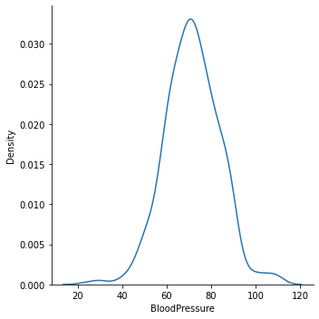

```python
sns.displot(pima['BloodPressure'], kind='kde')
plt.show()
```

#### Write your Answer here:

Ans 10:

- The distribution plot above, tells us that most of the individuals in our dataset have a bloodpressure of ~70. We can also observe taht our data folllows a nearly normal distribution with a slight left skew.

## Q 11. What is the 'BMI' for the person having the highest 'Glucose'? (1 Mark)

```python
pima[pima['Glucose']==pima['Glucose'].max()]['BMI']
```

```
661    42.9
Name: BMI, dtype: float64
```

#### Write your Answer here:

Ans 11:

- The BMI for the person with the highest Glucose is **42.9**

## Q12.

### 12.1 What is the mean of the variable 'BMI'?

### 12.2 What is the median of the variable 'BMI'?

### 12.3 What is the mode of the variable 'BMI'?

### 12.4 Are the three measures of central tendency equal?

### (3 Marks)

```python
m1 = pima['BMI'].mean()  #Mean
print('The Mean for the BMI is:', m1)
m2 = pima['BMI'].median()  #Median
print('The Median for the BMI is:', m2)
m3 = pima['BMI'].mode()[0]  #Mode
print('The Mode for the BMI is:', m3)
```

```
The Mean for the BMI is: 32.89022556390977
The Median for the BMI is: 32.8
The Mode for the BMI is: 32.0
```

#### Write your Answer here:

Ans 12:

- The Mean for the BMI is: 32.89022556390977
- The Median for the BMI is: 32.8
- The Mode for the BMI is: 32.0
- The three measures of central tendency for this dataset are not strictly equal, but they are similar enough to be considered as such for most calculations.

## Q13. How many women's 'Glucose' level is above the mean level of 'Glucose'? (1 Mark)

```python
print('There are',pima[pima['Glucose']>pima['Glucose'].mean()].shape[0], 'individuals in this dataset with a Glucose level above the Mean glucose level of', pima['Glucose'].mean())
```

```
There are 230 individuals in this dataset with a Glucose level above the Mean glucose level of 121.03007518796993
```

#### Write your Answer here:

Ans 13:

- Ther are 230 individuals with a Glucose level above the mean level of Glucose(~121).

## Q14. How many women have their 'BloodPressure' equal to the median of 'BloodPressure' and their 'BMI' less than the median of 'BMI'? (2 Marks)

```python
bloodPressureMedianAndBMIlessThanMedian=pima[(pima['BloodPressure']==pima['BloodPressure'].median()) & (pima['BMI']<pima['BMI'].median())]

print('There are', bloodPressureMedianAndBMIlessThanMedian.shape[0], 'individuals with a \'BloodPressure\' equal to the median of \'BloodPressure\' and a \'BMI\' less than the median of \'BMI\'.' )
bloodPressureMedianAndBMIlessThanMedian
```

```
There are 19 individuals with a 'BloodPressure' equal to the median of 'BloodPressure' and a 'BMI' less than the median of 'BMI'.
```

|  | Pregnancies | Glucose | BloodPressure | SkinThickness | Insulin | BMI | DiabetesPedigreeFunction | Age | Outcome |
| --- | --- | --- | --- | --- | --- | --- | --- | --- | --- |
| 14 | 5 | 166.0 | 72.0 | 19.0 | 175 | 25.8 | 0.587 | 51 | 1 |
| 103 | 1 | 81.0 | 72.0 | 18.0 | 40 | 26.6 | 0.283 | 24 | 0 |
| 175 | 8 | 179.0 | 72.0 | 42.0 | 130 | 32.7 | 0.719 | 36 | 1 |
| 205 | 5 | 111.0 | 72.0 | 28.0 | 0 | 23.9 | 0.407 | 27 | 0 |
| 325 | 1 | 157.0 | 72.0 | 21.0 | 168 | 25.6 | 0.123 | 24 | 0 |
| 330 | 8 | 118.0 | 72.0 | 19.0 | 0 | 23.1 | 1.476 | 46 | 0 |
| 380 | 1 | 107.0 | 72.0 | 30.0 | 82 | 30.8 | 0.821 | 24 | 0 |
| 393 | 4 | 116.0 | 72.0 | 12.0 | 87 | 22.1 | 0.463 | 37 | 0 |
| 446 | 1 | 100.0 | 72.0 | 12.0 | 70 | 25.3 | 0.658 | 28 | 0 |
| 460 | 9 | 120.0 | 72.0 | 22.0 | 56 | 20.8 | 0.733 | 48 | 0 |
| 488 | 4 | 99.0 | 72.0 | 17.0 | 0 | 25.6 | 0.294 | 28 | 0 |
| 497 | 2 | 81.0 | 72.0 | 15.0 | 76 | 30.1 | 0.547 | 25 | 0 |
| 510 | 12 | 84.0 | 72.0 | 31.0 | 0 | 29.7 | 0.297 | 46 | 1 |
| 541 | 3 | 128.0 | 72.0 | 25.0 | 190 | 32.4 | 0.549 | 27 | 1 |
| 568 | 4 | 154.0 | 72.0 | 29.0 | 126 | 31.3 | 0.338 | 37 | 0 |
| 644 | 3 | 103.0 | 72.0 | 30.0 | 152 | 27.6 | 0.730 | 27 | 0 |
| 717 | 10 | 94.0 | 72.0 | 18.0 | 0 | 23.1 | 0.595 | 56 | 0 |
| 737 | 8 | 65.0 | 72.0 | 23.0 | 0 | 32.0 | 0.600 | 42 | 0 |
| 765 | 5 | 121.0 | 72.0 | 23.0 | 112 | 26.2 | 0.245 | 30 | 0 |

#### Write your Answer here:

Ans 14:

- There are 19 individuals with a 'BloodPressure' equal to the median of 'BloodPressure' and a 'BMI' less than the median of 'BMI'.

## Q15. Create the pairplot for variables 'Glucose', 'SkinThickness' and 'DiabetesPedigreeFunction'. Write you observations from the plot. (4 Marks)

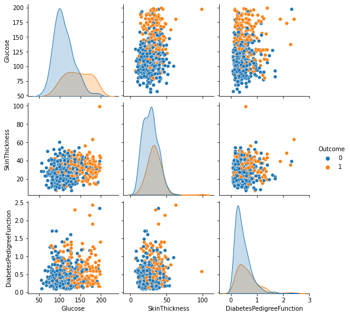

```python
sns.pairplot(data=pima,vars=['Glucose', 'SkinThickness', 'DiabetesPedigreeFunction'], hue='Outcome')
plt.show()
```

#### Write your Answer here:

Ans 15:

- From the pairplot above, and the current dataset, we observe **no meaningful correlation between the observed variables**.
- The KDE plots show basically identical distributions for two of the three variables, with the only difference being the frequency, which only tells us that most individuals do not have diabetes, which is to be expected.
- We can also observe that individuals with diabetes present hyperglycemia(*high blood sugar*), which is to be expected and is not a meaningful insight.
- There is a difference in distribution for `Glucose` in individuals with and without Diabetes. The KDE plot for this variable shows that there is more spread in the `Glucose` for individuals with Diabetes than for individuals without Diabetes.

## Q16. Plot the scatterplot between 'Glucose' and 'Insulin'. Write your observations from the plot. (2 Marks)

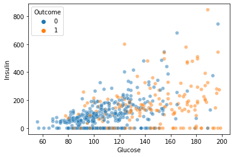

```python
sns.scatterplot(x='Glucose',y='Insulin',data=pima[pima['Glucose']!=0], hue='Outcome', alpha=0.5)
plt.show()
```

#### Write your Answer here:

Ans 16:

- We can not draw meaningful information from the plot above **with the current variables**.
- If we also took into account a `Time with Diabetes` variable and the `Age` variable we would be able to reduce the dispersion of the data and draw much more meaningful information, since those two (variables) are also factors in the '*Insulin to Glucose ratio*'.

## Q 17. Plot the boxplot for the 'Age' variable. Are there outliers? (2 Marks)

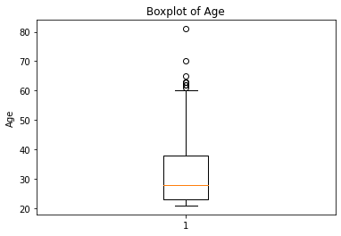

```
There are 9 'Age' outliers in the dataset.
```

```python
plt.boxplot(pima['Age'])

plt.title('Boxplot of Age')
plt.ylabel('Age')
plt.show()

Q1 = pima['Age'].quantile(0.25)
Q3 = pima['Age'].quantile(0.75)
IQR = Q3 - Q1
ageOutliers=((pima['Age'] < (Q1 - 1.5 * IQR)) | (pima['Age'] > (Q3 + 1.5 * IQR))).sum()

print('There are',ageOutliers,'\'Age\' outliers in the dataset.')
```

#### Write your Answer here:

Ans 17:

- There are 9 'Age' outliers in the dataset.

## Q18. Plot histograms for variable Age to understand the number of women in different Age groups given that they have diabetes or not. Explain both histograms and compare them. (3 Marks)

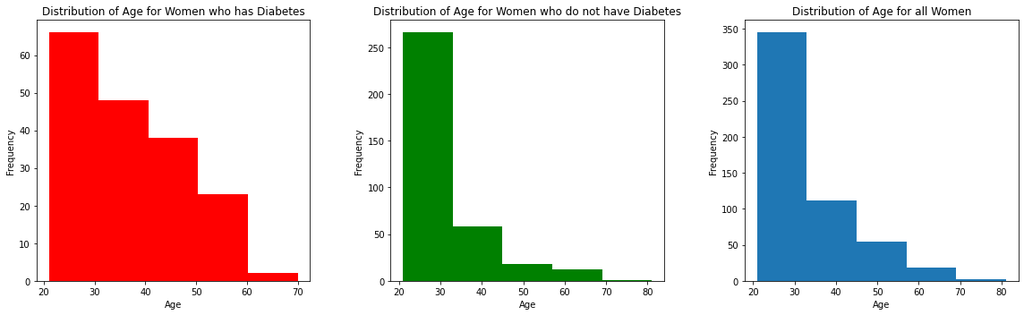

```python
plt.figure(figsize=(16, 5))

plt.subplot(131)

plt.hist(pima[pima['Outcome']==1]['Age'], bins = 5, color='r')
plt.title('Distribution of Age for Women who has Diabetes')
plt.xlabel('Age')
plt.ylabel('Frequency')

plt.subplot(132)

plt.hist(pima[pima['Outcome']==0]['Age'], bins = 5, color='g')
plt.title('Distribution of Age for Women who do not have Diabetes')
plt.xlabel('Age')
plt.ylabel('Frequency')

plt.subplot(133)

plt.hist(pima['Age'], bins = 5)
plt.title('Distribution of Age for all Women')
plt.xlabel('Age')
plt.ylabel('Frequency')

plt.tight_layout(w_pad=5)
```

#### Write your Answer here:

Ans 18:

- Distribution of Age for *Women who has Diabetes*
  - We can observe that Diabetes is present in every age group in our sample **except** for the 70-80 group which has 0 cases of Diabetes in our sample. We can infere that this is because individuals with diabetes in our population do not reach this age.
- Distribution of Age for *Women who do not have Diabetes*
  - We can see that there is a sharp drop in frequency from the 20-30 group to the rest of the Age groups, this may suggest that **individuals in our population develop Diabetes in their 20s**.
- Distribution of Age for *all Women*
  - This last histogram shows that the frequency of age has a sharp decline from the 20-30 Age group onwards, since the green histogram shows a similar distribution we can speculate that **there is a correlation between Diabetes and Mortality** in our population, but we need more data to prove this.

## Q 19. What is Inter Quartile Range of all the variables? Why is it used? Which plot visualizes the same? (2 Marks)

```python
Q1 = pima.quantile(0.25)
Q3 = pima.quantile(0.75)
IQR = Q3 - Q1
print(IQR)
```

```
Pregnancies                   4.00000
Glucose                      42.50000
BloodPressure                16.00000
SkinThickness                14.00000
Insulin                     165.25000
BMI                           9.02500
DiabetesPedigreeFunction      0.39975
Age                          15.00000
Outcome                       1.00000
dtype: float64
```

#### Write your Answer here:

Ans 19:

- We use the IQR to **eliminate outliers in our observations**.
- We can use a *boxplot* to visualize the IQR.

## Q 20. Find and visualize the the correlation matrix. Write your observations from the plot. (3 Marks)

```python
corr_matrix = pima.iloc[:,0:8].corr()

corr_matrix
```

|  | Pregnancies | Glucose | BloodPressure | SkinThickness | Insulin | BMI | DiabetesPedigreeFunction | Age |
| --- | --- | --- | --- | --- | --- | --- | --- | --- |
| Pregnancies | 1.000000 | 0.125330 | 0.204663 | 0.095085 | -0.006568 | 0.008576 | 0.007435 | 0.640747 |
| Glucose | 0.125330 | 1.000000 | 0.219178 | 0.226590 | 0.459905 | 0.247079 | 0.165817 | 0.278907 |
| BloodPressure | 0.204663 | 0.219178 | 1.000000 | 0.226072 | 0.007052 | 0.307357 | 0.008047 | 0.346939 |
| SkinThickness | 0.095085 | 0.226590 | 0.226072 | 1.000000 | 0.126240 | 0.647422 | 0.118636 | 0.161336 |
| Insulin | -0.006568 | 0.459905 | 0.007052 | 0.126240 | 1.000000 | 0.191168 | 0.151531 | 0.081126 |
| BMI | 0.008576 | 0.247079 | 0.307357 | 0.647422 | 0.191168 | 1.000000 | 0.151107 | 0.073438 |
| DiabetesPedigreeFunction | 0.007435 | 0.165817 | 0.008047 | 0.118636 | 0.151531 | 0.151107 | 1.000000 | 0.071654 |
| Age | 0.640747 | 0.278907 | 0.346939 | 0.161336 | 0.081126 | 0.073438 | 0.071654 | 1.000000 |

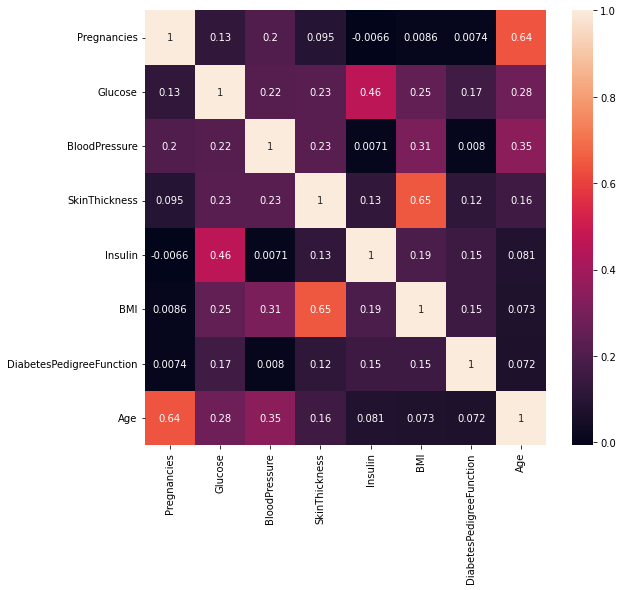

```python
plt.figure(figsize=(9,8))
sns.heatmap(corr_matrix, annot = True)

# display the plot
plt.show()
```

#### Write your Answer here:

Ans 20:

- We observe a *high correlation* between `SkinThickness` and `BMI`, this is to be expected.
- We observe a *high correlation* between `Pregnancies` and `Age`, this may sugest that individuals have more pregancies the older they get.
- We observe *medium correlation* between `Glucose` and `Insulin`, this is to be expected.
- We observe *medium correlation* between `BloodPressure` and `Age`, this may sugest an increase in blood pressure the older the individuals in our sample get.
- We observe *medium correlation* between `BloodPressure` and `BMI`, this suggests that an increase in `BMI` may result in an increase of `BloodPressure`, or viceversa.
- The rest of the variables have *little to no correlation*, hence, no more meaningful information can be extracted from this heatmap.